# SickKidsSucrose

### R^2

```r
# "visual_m", "motor_m",  "lateral_r_m", "auditory_m", "lateral_l_m", "cerebellum_m", "frontal_m"
vismodel <- roidata %>% filter(ROI == "visual_m") %>% lmer(H ~ Scan.Age + Birth.age + FD + (1|Subject.ID), REML=FALSE, data=.)
summary(vismodel)
```

```
## Linear mixed model fit by maximum likelihood  ['lmerMod']
## Formula: H ~ Scan.Age + Birth.age + FD + (1 | Subject.ID)
##    Data: .
##
##      AIC      BIC   logLik deviance df.resid
##   -202.1   -184.8    107.1   -214.1      126
##
## Scaled residuals:
##     Min      1Q  Median      3Q     Max
## -2.1724 -0.5469 -0.1019  0.4681  2.5268
##
## Random effects:
##  Groups     Name        Variance Std.Dev.
##  Subject.ID (Intercept) 0.00000  0.0000
##  Residual               0.01156  0.1075
## Number of obs: 132, groups:  Subject.ID, 97
##
## Fixed effects:
##              Estimate Std. Error t value
## (Intercept)  0.062594   0.133043   0.470
## Scan.Age     0.016953   0.002012   8.427
## Birth.age    0.004988   0.003684   1.354
## FD          -0.169432   0.036605  -4.629
##
## Correlation of Fixed Effects:
##           (Intr) Scn.Ag Brth.g
## Scan.Age  -0.663
## Birth.age -0.806  0.111
## FD        -0.152  0.157 -0.068
## optimizer (nloptwrap) convergence code: 0 (OK)
## boundary (singular) fit: see help('isSingular')
```

```r
r.squaredGLMM(vismodel)
```

```
##            R2m       R2c
## [1,] 0.4503889 0.4503889
```

```r
# "visual_m", "motor_m",  "lateral_r_m", "auditory_m", "lateral_l_m", "cerebellum_m", "frontal_m"
motormodel <- roidata %>% filter(ROI == "motor_m") %>% lmer(H ~ Scan.Age + Birth.age + FD + (1|Subject.ID), REML=FALSE, data=.)
summary(motormodel)
```

```
## Linear mixed model fit by maximum likelihood  ['lmerMod']
## Formula: H ~ Scan.Age + Birth.age + FD + (1 | Subject.ID)
##    Data: .
##
##      AIC      BIC   logLik deviance df.resid
##   -217.7   -200.4    114.8   -229.7      126
##
## Scaled residuals:
##     Min      1Q  Median      3Q     Max
## -2.0439 -0.6372 -0.0775  0.5696  3.5012
##
## Random effects:
##  Groups     Name        Variance  Std.Dev.
##  Subject.ID (Intercept) 0.0005322 0.02307
##  Residual               0.0097503 0.09874
## Number of obs: 132, groups:  Subject.ID, 97
##
## Fixed effects:
##              Estimate Std. Error t value
## (Intercept)  0.078689   0.126111   0.624
## Scan.Age     0.016967   0.001880   9.027
## Birth.age    0.004519   0.003526   1.282
## FD          -0.142755   0.034375  -4.153
##
## Correlation of Fixed Effects:
##           (Intr) Scn.Ag Brth.g
## Scan.Age  -0.654
## Birth.age -0.812  0.109
## FD        -0.150  0.157 -0.068
```

```r
r.squaredGLMM(motormodel)
```

```
##            R2m       R2c
## [1,] 0.4597583 0.4877201
```

```r
# "visual_m", "motor_m",  "lateral_r_m", "auditory_m", "lateral_l_m", "cerebellum_m", "frontal_m"
lateral_r_model <- roidata %>% filter(ROI == "lateral_r_m") %>% lmer(H ~ Scan.Age + Birth.age + FD + (1|Subject.ID), REML=FALSE, data=.)
summary(lateral_r_model)
```

```
## Linear mixed model fit by maximum likelihood  ['lmerMod']
## Formula: H ~ Scan.Age + Birth.age + FD + (1 | Subject.ID)
##    Data: .
##
##      AIC      BIC   logLik deviance df.resid
##   -234.0   -216.7    123.0   -246.0      126
##
## Scaled residuals:
##     Min      1Q  Median      3Q     Max
## -2.4796 -0.6256 -0.1144  0.5753  2.7497
##
## Random effects:
##  Groups     Name        Variance Std.Dev.
##  Subject.ID (Intercept) 0.000000 0.00000
##  Residual               0.009078 0.09528
## Number of obs: 132, groups:  Subject.ID, 97
##
## Fixed effects:
##              Estimate Std. Error t value
## (Intercept)  0.202587   0.117891   1.718
## Scan.Age     0.013954   0.001783   7.827
## Birth.age    0.002534   0.003265   0.776
## FD          -0.125697   0.032436  -3.875
##
## Correlation of Fixed Effects:
##           (Intr) Scn.Ag Brth.g
## Scan.Age  -0.663
## Birth.age -0.806  0.111
## FD        -0.152  0.157 -0.068
## optimizer (nloptwrap) convergence code: 0 (OK)
## boundary (singular) fit: see help('isSingular')
```

```r
r.squaredGLMM(lateral_r_model)
```

```
##            R2m       R2c
## [1,] 0.4026017 0.4026017
```

```r
# "visual_m", "motor_m",  "lateral_r_m", "auditory_m", "lateral_l_m", "cerebellum_m", "frontal_m", "hindbrain_m"
auditorymodel <- roidata %>% filter(ROI == "auditory_m") %>% lmer(H ~ Scan.Age + Birth.age + FD + (1|Subject.ID), REML=FALSE, data=.)
summary(auditorymodel)
```

```
## Linear mixed model fit by maximum likelihood  ['lmerMod']
## Formula: H ~ Scan.Age + Birth.age + FD + (1 | Subject.ID)
##    Data: .
##
##      AIC      BIC   logLik deviance df.resid
##   -239.0   -221.7    125.5   -251.0      126
##
## Scaled residuals:
##      Min       1Q   Median       3Q      Max
## -2.56465 -0.65715  0.02749  0.64095  2.64389
##
## Random effects:
##  Groups     Name        Variance Std.Dev.
##  Subject.ID (Intercept) 0.000000 0.0000
##  Residual               0.008743 0.0935
## Number of obs: 132, groups:  Subject.ID, 97
##
## Fixed effects:
##              Estimate Std. Error t value
## (Intercept)  0.218653   0.115692   1.890
## Scan.Age     0.013123   0.001749   7.501
## Birth.age    0.003511   0.003204   1.096
## FD          -0.111701   0.031831  -3.509
##
## Correlation of Fixed Effects:
##           (Intr) Scn.Ag Brth.g
## Scan.Age  -0.663
## Birth.age -0.806  0.111
## FD        -0.152  0.157 -0.068
## optimizer (nloptwrap) convergence code: 0 (OK)
## boundary (singular) fit: see help('isSingular')
```

```r
r.squaredGLMM(auditorymodel)
```

```
##            R2m       R2c
## [1,] 0.3756638 0.3756638
```

```r
# "visual_m", "motor_m",  "lateral_r_m", "auditory_m", "lateral_l_m", "cerebellum_m", "frontal_m", "hindbrain_m"
lateral_l_model <- roidata %>% filter(ROI == "lateral_l_m") %>% lmer(H ~ Scan.Age + Birth.age + FD + (1|Subject.ID), REML=FALSE, data=.)
summary(lateral_l_model)
```

```
## Linear mixed model fit by maximum likelihood  ['lmerMod']
## Formula: H ~ Scan.Age + Birth.age + FD + (1 | Subject.ID)
##    Data: .
##
##      AIC      BIC   logLik deviance df.resid
##   -242.6   -225.3    127.3   -254.6      126
##
## Scaled residuals:
##      Min       1Q   Median       3Q      Max
## -2.86082 -0.63916 -0.08798  0.54685  2.47935
##
## Random effects:
##  Groups     Name        Variance Std.Dev.
##  Subject.ID (Intercept) 0.000000 0.00000
##  Residual               0.008512 0.09226
## Number of obs: 132, groups:  Subject.ID, 97
##
## Fixed effects:
##              Estimate Std. Error t value
## (Intercept)  0.129814   0.114153   1.137
## Scan.Age     0.013024   0.001726   7.545
## Birth.age    0.006390   0.003161   2.021
## FD          -0.136458   0.031408  -4.345
##
## Correlation of Fixed Effects:
##           (Intr) Scn.Ag Brth.g
## Scan.Age  -0.663
## Birth.age -0.806  0.111
## FD        -0.152  0.157 -0.068
## optimizer (nloptwrap) convergence code: 0 (OK)
## boundary (singular) fit: see help('isSingular')
```

```r
r.squaredGLMM(lateral_l_model)
```

```
##            R2m       R2c
## [1,] 0.4039635 0.4039635
```

```r
# "visual_m", "motor_m",  "lateral_r_m", "auditory_m", "lateral_l_m", "cerebellum_m", "frontal_m", "hindbrain_m"
cerebellummodel <- roidata %>% filter(ROI == "cerebellum_m") %>% lmer(H ~ Scan.Age + Birth.age + FD + (1|Subject.ID), REML=FALSE, data=.)
summary(cerebellummodel)
```

```
## Linear mixed model fit by maximum likelihood  ['lmerMod']
## Formula: H ~ Scan.Age + Birth.age + FD + (1 | Subject.ID)
##    Data: .
##
##      AIC      BIC   logLik deviance df.resid
##   -244.3   -227.0    128.2   -256.3      126
##
## Scaled residuals:
##     Min      1Q  Median      3Q     Max
## -2.3226 -0.6855 -0.0915  0.6876  3.3715
##
## Random effects:
##  Groups     Name        Variance Std.Dev.
##  Subject.ID (Intercept) 0.000000 0.00000
##  Residual               0.008397 0.09164
## Number of obs: 132, groups:  Subject.ID, 97
##
## Fixed effects:
##              Estimate Std. Error t value
## (Intercept)  0.236094   0.113383   2.082
## Scan.Age     0.011407   0.001715   6.653
## Birth.age    0.003007   0.003140   0.958
## FD          -0.050511   0.031196  -1.619
##
## Correlation of Fixed Effects:
##           (Intr) Scn.Ag Brth.g
## Scan.Age  -0.663
## Birth.age -0.806  0.111
## FD        -0.152  0.157 -0.068
## optimizer (nloptwrap) convergence code: 0 (OK)
## boundary (singular) fit: see help('isSingular')
```

```r
r.squaredGLMM(cerebellummodel)
```

```
##            R2m       R2c
## [1,] 0.2823449 0.2823449
```

```r
# "visual_m", "motor_m",  "lateral_r_m", "auditory_m", "lateral_l_m", "cerebellum_m", "frontal_m", "hindbrain_m"
frontalmodel <- roidata %>% filter(ROI == "frontal_m") %>% lmer(H ~ Scan.Age + Birth.age + FD + (1|Subject.ID), REML=FALSE, data=.)
summary(frontalmodel)
```

```
## Linear mixed model fit by maximum likelihood  ['lmerMod']
## Formula: H ~ Scan.Age + Birth.age + FD + (1 | Subject.ID)
##    Data: .
##
##      AIC      BIC   logLik deviance df.resid
##   -218.2   -200.9    115.1   -230.2      126
##
## Scaled residuals:
##      Min       1Q   Median       3Q      Max
## -2.61187 -0.60491  0.04343  0.47719  2.48578
##
## Random effects:
##  Groups     Name        Variance Std.Dev.
##  Subject.ID (Intercept) 0.00000  0.0000
##  Residual               0.01024  0.1012
## Number of obs: 132, groups:  Subject.ID, 97
##
## Fixed effects:
##              Estimate Std. Error t value
## (Intercept)  0.244669   0.125181   1.955
## Scan.Age     0.009523   0.001893   5.031
## Birth.age    0.005672   0.003467   1.636
## FD          -0.062455   0.034442  -1.813
##
## Correlation of Fixed Effects:
##           (Intr) Scn.Ag Brth.g
## Scan.Age  -0.663
## Birth.age -0.806  0.111
## FD        -0.152  0.157 -0.068
## optimizer (nloptwrap) convergence code: 0 (OK)
## boundary (singular) fit: see help('isSingular')
```

```r
r.squaredGLMM(frontalmodel)
```

```
##            R2m       R2c
## [1,] 0.2012003 0.2012003
```

```r
# "visual_m", "motor_m",  "lateral_r_m", "auditory_m", "lateral_l_m", "cerebellum_m", "frontal_m", "hindbrain_m"
salientmodel <- roidata %>% filter(ROI == "salient_m") %>% lmer(H ~ Scan.Age + Birth.age + FD + (1|Subject.ID), REML=FALSE, data=.)
summary(salientmodel)
```

```
## Linear mixed model fit by maximum likelihood  ['lmerMod']
## Formula: H ~ Scan.Age + Birth.age + FD + (1 | Subject.ID)
##    Data: .
##
##      AIC      BIC   logLik deviance df.resid
##   -223.3   -206.0    117.7   -235.3      126
##
## Scaled residuals:
##      Min       1Q   Median       3Q      Max
## -1.86320 -0.61251 -0.04216  0.63651  2.68283
##
## Random effects:
##  Groups     Name        Variance Std.Dev.
##  Subject.ID (Intercept) 0.000000 0.00000
##  Residual               0.009845 0.09922
## Number of obs: 132, groups:  Subject.ID, 97
##
## Fixed effects:
##              Estimate Std. Error t value
## (Intercept)  0.328475   0.122768   2.676
## Scan.Age     0.010635   0.001856   5.729
## Birth.age    0.001693   0.003400   0.498
## FD          -0.112907   0.033778  -3.343
##
## Correlation of Fixed Effects:
##           (Intr) Scn.Ag Brth.g
## Scan.Age  -0.663
## Birth.age -0.806  0.111
## FD        -0.152  0.157 -0.068
## optimizer (nloptwrap) convergence code: 0 (OK)
## boundary (singular) fit: see help('isSingular')
```

```r
r.squaredGLMM(salientmodel)
```

```
##            R2m       R2c
## [1,] 0.2823384 0.2823384
```

```r
# "visual_m", "motor_m",  "lateral_r_m", "auditory_m", "lateral_l_m", "cerebellum_m", "frontal_m", "hindbrain_m"
hindbrainmodel <- roidata %>% filter(ROI == "hindbrain_m") %>% lmer(H ~ Scan.Age + Birth.age + FD + (1|Subject.ID), REML=FALSE, data=.)
summary(hindbrainmodel)
```

```
## Linear mixed model fit by maximum likelihood  ['lmerMod']
## Formula: H ~ Scan.Age + Birth.age + FD + (1 | Subject.ID)
##    Data: .
##
##      AIC      BIC   logLik deviance df.resid
##   -241.3   -224.1    126.7   -253.3      126
##
## Scaled residuals:
##      Min       1Q   Median       3Q      Max
## -2.40730 -0.55835  0.01156  0.55746  2.51618
##
## Random effects:
##  Groups     Name        Variance Std.Dev.
##  Subject.ID (Intercept) 0.00000  0.00000
##  Residual               0.00859  0.09268
## Number of obs: 132, groups:  Subject.ID, 97
##
## Fixed effects:
##              Estimate Std. Error t value
## (Intercept)  0.183486   0.114675   1.600
## Scan.Age     0.011948   0.001734   6.890
## Birth.age    0.005670   0.003176   1.785
## FD          -0.087752   0.031551  -2.781
##
## Correlation of Fixed Effects:
##           (Intr) Scn.Ag Brth.g
## Scan.Age  -0.663
## Birth.age -0.806  0.111
## FD        -0.152  0.157 -0.068
## optimizer (nloptwrap) convergence code: 0 (OK)
## boundary (singular) fit: see help('isSingular')
```

```r
r.squaredGLMM(hindbrainmodel)
```

```
##            R2m       R2c
## [1,] 0.3256264 0.3256264
```

### Estimated Marginal Means

```
##  Scan.Age ROI          emmean     SE  df lower.CL upper.CL
##      32.7 auditory_m    0.681 0.0117 155    0.658    0.704
##      40.9 auditory_m    0.808 0.0112 139    0.786    0.830
##      32.7 cerebellum_m  0.658 0.0109 158    0.637    0.680
##      40.9 cerebellum_m  0.765 0.0104 143    0.744    0.785
##      32.7 frontal_m     0.672 0.0115 156    0.649    0.694
##      40.9 frontal_m     0.764 0.0109 140    0.742    0.785
##      32.7 hindbrain_m   0.679 0.0112 157    0.656    0.701
##      40.9 hindbrain_m   0.792 0.0107 141    0.771    0.813
##      32.7 lateral_l_m   0.657 0.0113 157    0.635    0.680
##      40.9 lateral_l_m   0.783 0.0108 141    0.761    0.804
##      32.7 lateral_r_m   0.659 0.0117 155    0.635    0.682
##      40.9 lateral_r_m   0.794 0.0112 139    0.772    0.816
##      32.7 motor_m       0.680 0.0118 155    0.657    0.704
##      40.9 motor_m       0.841 0.0113 139    0.818    0.863
##      32.7 salient_m     0.659 0.0117 155    0.636    0.682
##      40.9 salient_m     0.767 0.0112 139    0.745    0.789
##      32.7 visual_m      0.662 0.0123 152    0.638    0.687
##      40.9 visual_m      0.826 0.0118 137    0.803    0.850
##
## Degrees-of-freedom method: kenward-roger
## Confidence level used: 0.95
```

```r
emmeans_ScanAge33and41.df <- as.data.frame(emmeans_ScanAge33and41)
emmeans_ScanAge33and41.df %>% filter(Scan.Age == "32.7") %>% summarise(mean = mean(emmean), range = range(emmean))
```

```
##        mean     range
## 1 0.6673929 0.6571941
## 2 0.6673929 0.6807907
```

```r
emmeans_ScanAge33and41.df %>% filter(Scan.Age == "40.9") %>% summarise(mean = mean(emmean), range = range(emmean))
```

```
##        mean     range
## 1 0.7932549 0.7637062
## 2 0.7932549 0.8405497
```

```
## ROI = auditory_m:
##  contrast                    estimate     SE  df t.ratio p.value
##  Scan.Age40.9 - Scan.Age32.7   0.1273 0.0118 398  10.752  <.0001
##
## ROI = cerebellum_m:
##  contrast                    estimate     SE  df t.ratio p.value
##  Scan.Age40.9 - Scan.Age32.7   0.1064 0.0117 383   9.120  <.0001
##
## ROI = frontal_m:
##  contrast                    estimate     SE  df t.ratio p.value
##  Scan.Age40.9 - Scan.Age32.7   0.0922 0.0118 393   7.820  <.0001
##
## ROI = hindbrain_m:
##  contrast                    estimate     SE  df t.ratio p.value
##  Scan.Age40.9 - Scan.Age32.7   0.1132 0.0117 389   9.648  <.0001
##
## ROI = lateral_l_m:
##  contrast                    estimate     SE  df t.ratio p.value
##  Scan.Age40.9 - Scan.Age32.7   0.1256 0.0118 391  10.685  <.0001
##
## ROI = lateral_r_m:
##  contrast                    estimate     SE  df t.ratio p.value
##  Scan.Age40.9 - Scan.Age32.7   0.1357 0.0118 398  11.462  <.0001
##
## ROI = motor_m:
##  contrast                    estimate     SE  df t.ratio p.value
##  Scan.Age40.9 - Scan.Age32.7   0.1603 0.0119 400  13.505  <.0001
##
## ROI = salient_m:
##  contrast                    estimate     SE  df t.ratio p.value
##  Scan.Age40.9 - Scan.Age32.7   0.1079 0.0118 398   9.118  <.0001
##
## ROI = visual_m:
##  contrast                    estimate     SE  df t.ratio p.value
##  Scan.Age40.9 - Scan.Age32.7   0.1641 0.0120 410  13.686  <.0001
##
## Degrees-of-freedom method: kenward-roger
```

```
## Scan.Age = 32.7:
##  contrast                    estimate     SE  df t.ratio p.value
##  auditory_m - cerebellum_m   0.022308 0.0125 153   1.784  1.0000
##  auditory_m - frontal_m      0.009235 0.0125 153   0.742  1.0000
##  auditory_m - hindbrain_m    0.002170 0.0125 153   0.174  1.0000
##  auditory_m - lateral_l_m    0.023597 0.0125 153   1.893  1.0000
##  auditory_m - lateral_r_m    0.022233 0.0125 153   1.785  1.0000
##  auditory_m - motor_m        0.000555 0.0125 153   0.045  1.0000
##  auditory_m - salient_m      0.021951 0.0125 153   1.763  1.0000
##  auditory_m - visual_m       0.018531 0.0125 153   1.483  1.0000
##  cerebellum_m - frontal_m   -0.013073 0.0125 153  -1.048  1.0000
##  cerebellum_m - hindbrain_m -0.020138 0.0125 153  -1.616  1.0000
##  cerebellum_m - lateral_l_m  0.001289 0.0125 153   0.103  1.0000
##  cerebellum_m - lateral_r_m -0.000075 0.0125 153  -0.006  1.0000
##  cerebellum_m - motor_m     -0.021753 0.0125 153  -1.736  1.0000
##  cerebellum_m - salient_m   -0.000357 0.0125 153  -0.029  1.0000
##  cerebellum_m - visual_m    -0.003777 0.0126 154  -0.299  1.0000
##  frontal_m - hindbrain_m    -0.007065 0.0125 153  -0.567  1.0000
##  frontal_m - lateral_l_m     0.014361 0.0125 153   1.153  1.0000
##  frontal_m - lateral_r_m     0.012998 0.0125 153   1.043  1.0000
##  frontal_m - motor_m        -0.008680 0.0125 153  -0.696  1.0000
##  frontal_m - salient_m       0.012715 0.0125 153   1.021  1.0000
##  frontal_m - visual_m        0.009296 0.0125 153   0.742  1.0000
##  hindbrain_m - lateral_l_m   0.021426 0.0125 153   1.721  1.0000
##  hindbrain_m - lateral_r_m   0.020063 0.0125 153   1.608  1.0000
##  hindbrain_m - motor_m      -0.001615 0.0125 153  -0.129  1.0000
##  hindbrain_m - salient_m     0.019780 0.0125 153   1.586  1.0000
##  hindbrain_m - visual_m      0.016361 0.0126 153   1.302  1.0000
##  lateral_l_m - lateral_r_m  -0.001364 0.0125 153  -0.109  1.0000
##  lateral_l_m - motor_m      -0.023041 0.0125 153  -1.846  1.0000
##  lateral_l_m - salient_m    -0.001646 0.0125 153  -0.132  1.0000
##  lateral_l_m - visual_m     -0.005065 0.0125 153  -0.404  1.0000
##  lateral_r_m - motor_m      -0.021678 0.0125 153  -1.739  1.0000
##  lateral_r_m - salient_m    -0.000282 0.0125 153  -0.023  1.0000
##  lateral_r_m - visual_m     -0.003702 0.0125 153  -0.297  1.0000
##  motor_m - salient_m         0.021395 0.0125 153   1.718  1.0000
##  motor_m - visual_m          0.017976 0.0125 153   1.438  1.0000
##  salient_m - visual_m       -0.003419 0.0125 153  -0.274  1.0000
##
## Scan.Age = 40.9:
```

[output cut: 25 more lines]

```
##  hindbrain_m - salient_m     0.025039 0.0116 142   2.154  0.4736
##  hindbrain_m - visual_m     -0.034559 0.0117 143  -2.949  0.0856
##  lateral_l_m - lateral_r_m  -0.011467 0.0116 142  -0.987  1.0000
##  lateral_l_m - motor_m      -0.057718 0.0116 142  -4.961  0.0001
##  lateral_l_m - salient_m     0.016057 0.0116 142   1.382  1.0000
##  lateral_l_m - visual_m     -0.043541 0.0117 143  -3.724  0.0073
##  lateral_r_m - motor_m      -0.046251 0.0116 142  -3.981  0.0030
##  lateral_r_m - salient_m     0.027524 0.0116 142   2.371  0.3244
##  lateral_r_m - visual_m     -0.032074 0.0116 142  -2.757  0.1385
##  motor_m - salient_m         0.073775 0.0116 142   6.359  <.0001
##  motor_m - visual_m          0.014177 0.0116 142   1.217  1.0000
##  salient_m - visual_m       -0.059598 0.0117 142  -5.115  <.0001
##
## Degrees-of-freedom method: kenward-roger
## P value adjustment: holm method for 36 tests
```

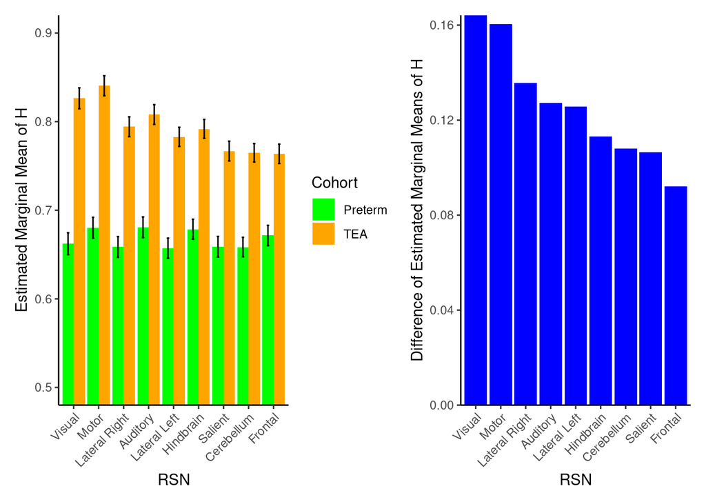

```r
png(file="Figure5_differencebarblots.png", width=7, height=4, units="in", res=300)
emmeanplot + diffplot #+ plot_layout(heights = 3, widths=1, ncol=2)
dev.off()
```

## H in GM vs GA

Let’s test our second hypothesis: H in GM will be affected by the baby’s GA. Let’s look at just the TEA (n = 69).

First we will set up our full model [note: this is a simple multiple linear regression now]:

HinGM ~ GA + PMA + FD

```
##
## Call:
## lm(formula = gm_m ~ Birth.age + Scan.Age + FD, data = TEAonly,
##     REML = FALSE)
##
## Residuals:
##       Min        1Q    Median        3Q       Max
## -0.177416 -0.060929  0.008584  0.063878  0.242896
##
## Coefficients:
##              Estimate Std. Error t value Pr(>|t|)
## (Intercept)  0.033270   0.193021   0.172   0.8637
## Birth.age    0.001900   0.004318   0.440   0.6614
## Scan.Age     0.018376   0.003926   4.680  1.5e-05 ***
## FD          -0.097449   0.039740  -2.452   0.0169 *
## ---
## Signif. codes:  0 '***' 0.001 '**' 0.01 '*' 0.05 '.' 0.1 ' ' 1
##
## Residual standard error: 0.09143 on 65 degrees of freedom
## Multiple R-squared:  0.3445, Adjusted R-squared:  0.3142
## F-statistic: 11.39 on 3 and 65 DF,  p-value: 4.289e-06
```

And now let’s test against our null model:

HinGM ~ PMA + FD

| Res.Df | RSS | Df | Sum of Sq | F | Pr(>F) |
| --- | --- | --- | --- | --- | --- |
| 65 | 0.5 | NA | NA | NA | NA |
| 66 | 0.5 | -1 | 0 | 0.2 | 0.661 |

It doesn’t look like it. Let’s visualize this:

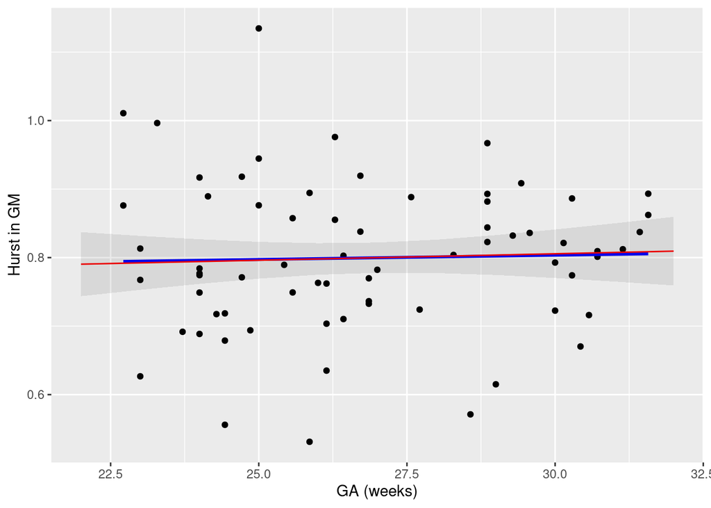

We can’t see the two different slopes as they appear to be identical: including PMA and FD hasn’t affected the correlation between HinGM and GA.